# NACP Project–Well Classification

Annette Hilton

05/03/2022

# Introduction

This project is an examination of early 1900s (~1890-1906) groundwater conditions in the North Atlantic Coastal Plain (NACP) as compared to present day (2010-2021).

The purpose of this Rmd is to:

1. Determine well-aquifer classification
2. Compare artesian conditions

## Attach Packages and Data

```r
# Attach packages

library(plyr) # Be sure to load `plyr()` first, otherwise other functions in tidyverse break!
library(tidyverse)
library(here)
library(janitor)
library(naniar)
library(data.table)
library(knitr)

# Disable scientific notation

options(scipen=999)
```

# Overview of North Atlantic Coastal Plain Aquifer System

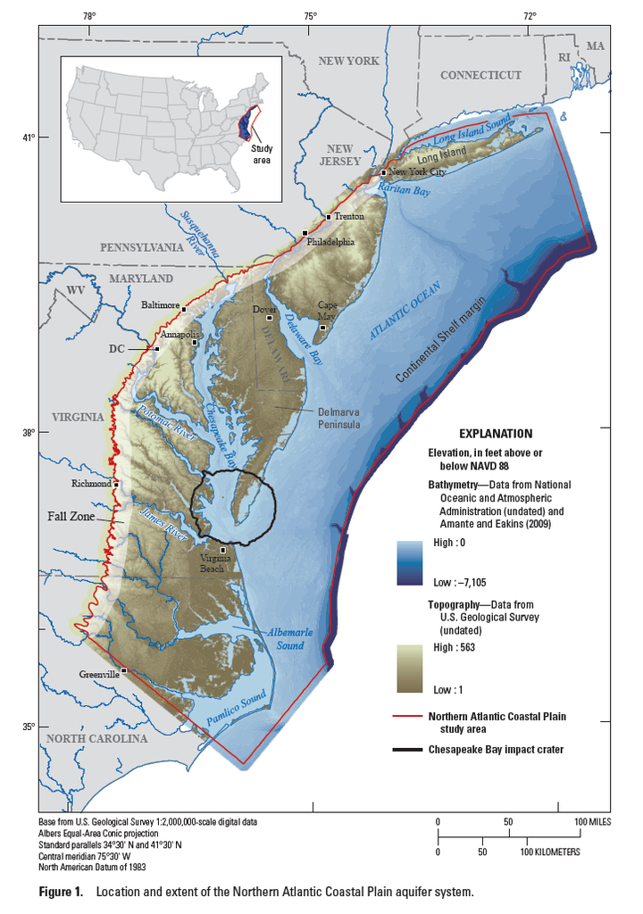

Figure 1. North Atlantic Coastal Plain Aquifer System aerial extent (Masterson et al., 2016)

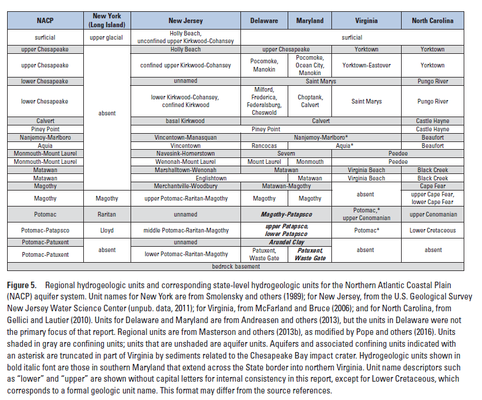

Figure 2. North Atlantic Coastal Plain Aquifer System aquifer units (Masterson et al., 2016)

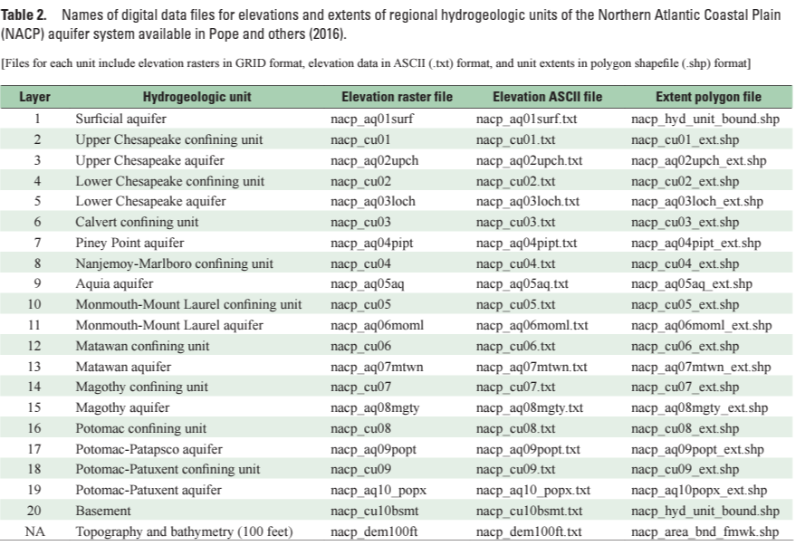

Figure 3. North Atlantic Coastal Plain Aquifer System hydrogeological GIS layers (Pope et al., 2016)

## ArcGIS Data Analysis

The following steps were performed in ArcGIS:

Hydrogeological data: Arcfile = “nacp_classify” (ArcPro)

1. Hydrogeologic layers (raster files)
2. Modern wells from NACP (USGS) (processed in Rmd `modern_data_cleaning.Rmd`) and early 1900s data (early1900s_dem_wgs84_final.txt)
3. Use tool “Extract multi values to points” to determine well location intersection with geological raster layers
4. Export resulting well data as a text files

### Hydrogeological data

```r
# Read in modern data file from Arc
# Rename columns

nacp_mod_fromarc <- readr::read_csv(here::here("data", "nacp", "nacp_modern_classify.txt")) %>%
  clean_names() %>%
  rename(nacp_aq01s = nacp_aq01surf_1,
         nacp_cu01 = nacp_cu01_1,
         nacp_aq02u = nacp_aq02upch_1,
         nacp_cu02 = nacp_cu02_1,
         nacp_aq03l = nacp_aq03loch_1,
         nacp_cu03 = nacp_cu03_1,
         nacp_aq04p = nacp_aq04pipt_1,
         nacp_cu04 = nacp_cu04_1,
         nacp_aq05a = nacp_aq05aq_1,
         nacp_cu05 = nacp_cu05_1,
         nacp_aq06m = nacp_aq06moml_1,
         nacp_cu06 = nacp_cu06_1,
         nacp_aq07m = nacp_aq07mtwn_1,
         nacp_cu07 = nacp_cu07_1,
         nacp_aq08m = nacp_aq08mgty_1,
         nacp_cu08 = nacp_cu08_1,
         nacp_aq09p = nacp_aq09popt_1,
         nacp_cu09 = nacp_cu09_1,
         nacp_aq10p = nacp_aq10popx_1,
         nacp_cu10b = nacp_cu10bsmt_1)

# Read in early 1900s data file from Arc
# Rename columns

nacp_early1900s_fromarc <- readr::read_csv(here::here("data", "nacp", "nacp_1900s_classify.txt")) %>%
  clean_names() %>%
  rename(nacp_aq01s = nacp_aq01surf,
         nacp_aq02u = nacp_aq02upch,
         nacp_aq03l = nacp_aq03loch,
         nacp_aq04p = nacp_aq04pipt,
         nacp_aq05a = nacp_aq05aq,
         nacp_aq06m = nacp_aq06moml,
         nacp_aq07m = nacp_aq07mtwn,
         nacp_aq08m = nacp_aq08mgty,
         nacp_aq09p = nacp_aq09popt,
         nacp_aq10p = nacp_aq10popx,
         nacp_cu10b = nacp_cu10bsmt)
```

### NACP Aquifer Information

Hydrogeologic Layer Surfaces:

- Surficial aquifer (nacp_aq01_surf) == (nacp_aq01s)
- Upper Chesapeake confining unit (nacp_cu01)
- Upper Chesapeake aquifer (nacp_aq02upch) == (nacp_aq02u)
- Lower Chesapeake confining unit (nacp_cu02)
- Lower Chesapeake aquifer (nacp_aq03loch) == (nacp_aq03l)
- Calvert confining unit (nacp_cu03)
- Piney Point aquifer (nacp_aq04pipt) == (nacp_aq04p)
- Nanjemoy-Marlboro confining unit (nacp_cu04)
- Aquia aquifer (nacp_aq05aq) == (nacp_aq05a)
- Monmouth-Mount Laurel confining unit (nacp_cu05)
- Monmouth-Mount Laurel aquifer (nacp_aq06moml) == (nacp_aq06m)
- Matawan confining unit (nacp_cu06)
- Matawan aquifer (nacp_aq07mtwn) == (nacp_aq07m)
- Magothy confining unit (nacp_cu07)
- Magothy aquifer (nacp_aq08mgty) == (nacp_aq08m)
- Potomac confining unit (nacp_cu08)
- Potomac-Patapsco aquifer (nacp_aq09popt) == (nacp_aq09p)
- Potomac-Patuxent confining unit (nacp_cu09)
- Potomac-Patuxent aquifer (nacp_aq10_popx) == (nacp_aq10_p)
- Basement (nacp_cu10bsmt) == (nacp_cu10b)

Unit Range (ft):

- Surficial aquifer: 481 (-308)
- Upper Chesapeake confining unit: 129 (-354)
- Upper Chesapeake aquifer: 114 (-383)
- Lower Chesapeake confining unit: 150 (-850)
- Lower Chesapeake aquifer: 215 (-1007)
- Calvert confining unit: 236 (-1671)
- Piney Point aquifer: 92 (-1516)
- Nanjemoy-Marlboro confining unit: 233 (-1720)
- Aquia aquifer: 228 (-1323)
- Monmouth-Mount Laurel confining unit: 214 (-1981)
- Monmouth-Mount Laurel aquifer: 143 (-2377)
- Matawan confining unit: 118 (-2439)
- Matawan aquifer: 62 (-2501)
- Magothy confining unit: 130 (-2532)
- Magothy aquifer: 187 (-2995)
- Potomac confining unit: 198 (-3380)
- Potomac-Patapsco aquifer: 229 (-3602)
- Potomac-Patuxent confining unit: 408 (-5373)
- Potomac-Patuxent aquifer: 408 (-5373)
- Basement: 400 (-9031)

### Aquifer analysis

- Find well bottom
- Remove observations that do not fall within NACP (all NAs)

```r
# Add a column that is elevation minus well depth
# Add column to remove rows if nacp_aq01s:nacp_cu10b are all NAs (does not intersect with NACP)

# Modern data

nacp_analysis_mod <- nacp_mod_fromarc %>%
  mutate(topo_ft = rastervalu * 3.28084) %>%
  mutate(well_bottom = topo_ft - well_depth_va) %>%
   mutate(keep =
           ifelse(is.na(nacp_aq01s) & is.na(nacp_cu01) & is.na(nacp_aq02u)
                  & is.na(nacp_cu02) & is.na(nacp_aq03l) & is.na(nacp_cu03)
                  & is.na(nacp_aq04p) & is.na(nacp_cu04) & is.na(nacp_aq05a)
                  & is.na(nacp_cu05) & is.na(nacp_aq06m) & is.na(nacp_cu06)
                  & is.na(nacp_aq07m) & is.na(nacp_cu07) & is.na(nacp_aq08m)
                  & is.na(nacp_cu08) & is.na(nacp_aq09p) & is.na(nacp_cu09)
                  & is.na(nacp_aq10p) & is.na(nacp_cu10b), "NA", "keep")) %>%
  filter(!keep == "NA")

# 1900s data

nacp_analysis_1900 <- nacp_early1900s_fromarc %>%
  mutate(topo_ft = ned10m_bilinear_cusa_albers102003 * 3.28084) %>%
  mutate(well_bottom = topo_ft - well_depth_ft) %>%
   mutate(keep =
           ifelse(is.na(nacp_aq01s) & is.na(nacp_cu01) & is.na(nacp_aq02u)
                  & is.na(nacp_cu02) & is.na(nacp_aq03l) & is.na(nacp_cu03)
                  & is.na(nacp_aq04p) & is.na(nacp_cu04) & is.na(nacp_aq05a)
                  & is.na(nacp_cu05) & is.na(nacp_aq06m) & is.na(nacp_cu06)
                  & is.na(nacp_aq07m) & is.na(nacp_cu07) & is.na(nacp_aq08m)
                  & is.na(nacp_cu08) & is.na(nacp_aq09p) & is.na(nacp_cu09)
                  & is.na(nacp_aq10p) & is.na(nacp_cu10b), "NA", "keep")) %>%
  filter(!keep == "NA")
```

#### Classify each well to an aquifer unit

```r
# Code for assigning each well to an aquifer unit
# Not elegant but currently works!

# Modern data

nacp_class_mod <- nacp_analysis_mod %>%
  rowwise() %>%
  mutate(aquifer =
        ifelse(well_bottom < topo_ft & well_bottom >= max(nacp_cu01, nacp_aq02u, nacp_cu02,
                                                            nacp_aq03l, nacp_cu03, nacp_aq04p,
                                                            nacp_cu04, nacp_aq05a, nacp_cu05,
                                                            nacp_aq06m, nacp_cu06, nacp_aq07m,
                                                            nacp_cu07, nacp_aq08m, nacp_cu08,
                                                            nacp_aq09p, nacp_cu09, nacp_aq10p,
                                                            nacp_cu10b, na.rm = TRUE), "surf",
        ifelse(well_bottom < nacp_cu01 & well_bottom >= max(nacp_aq02u, nacp_cu02,
                                                            nacp_aq03l, nacp_cu03, nacp_aq04p,
                                                            nacp_cu04, nacp_aq05a, nacp_cu05,
                                                            nacp_aq06m, nacp_cu06, nacp_aq07m,
                                                            nacp_cu07, nacp_aq08m, nacp_cu08,
                                                            nacp_aq09p, nacp_cu09, nacp_aq10p,
                                                            nacp_cu10b, na.rm = TRUE),"nacp_cu01",
        ifelse(well_bottom < nacp_aq02u & well_bottom >= max(nacp_cu02,
                                                            nacp_aq03l, nacp_cu03, nacp_aq04p,
                                                            nacp_cu04, nacp_aq05a, nacp_cu05,
                                                            nacp_aq06m, nacp_cu06, nacp_aq07m,
                                                            nacp_cu07, nacp_aq08m, nacp_cu08,
                                                            nacp_aq09p, nacp_cu09, nacp_aq10p,
                                                            nacp_cu10b, na.rm = TRUE), "nacp_aq02u",
        ifelse(well_bottom < nacp_cu02 & well_bottom >= max(nacp_aq03l, nacp_cu03, nacp_aq04p,
                                                            nacp_cu04, nacp_aq05a, nacp_cu05,
                                                            nacp_aq06m, nacp_cu06, nacp_aq07m,
                                                            nacp_cu07, nacp_aq08m, nacp_cu08,
                                                            nacp_aq09p, nacp_cu09, nacp_aq10p,
                                                            nacp_cu10b, na.rm = TRUE), "nacp_cu02",
        ifelse(well_bottom < nacp_aq03l & well_bottom >= max(nacp_cu03, nacp_aq04p,
                                                            nacp_cu04, nacp_aq05a, nacp_cu05,
                                                            nacp_aq06m, nacp_cu06, nacp_aq07m,
                                                            nacp_cu07, nacp_aq08m, nacp_cu08,
                                                            nacp_aq09p, nacp_cu09, nacp_aq10p,
                                                            nacp_cu10b, na.rm = TRUE), "nacp_aq03l",
        ifelse(well_bottom < nacp_cu03 & well_bottom >= max(nacp_aq04p,
                                                            nacp_cu04, nacp_aq05a, nacp_cu05,
                                                            nacp_aq06m, nacp_cu06, nacp_aq07m,
                                                            nacp_cu07, nacp_aq08m, nacp_cu08,
                                                            nacp_aq09p, nacp_cu09, nacp_aq10p,
                                                            nacp_cu10b, na.rm = TRUE), "nacp_cu03",
        ifelse(well_bottom < nacp_aq04p & well_bottom >= max(nacp_cu04, nacp_aq05a, nacp_cu05,
                                                            nacp_aq06m, nacp_cu06, nacp_aq07m,
                                                            nacp_cu07, nacp_aq08m, nacp_cu08,
                                                            nacp_aq09p, nacp_cu09, nacp_aq10p,
                                                            nacp_cu10b, na.rm = TRUE), "nacp_aq04p",
        ifelse(well_bottom < nacp_cu04 & well_bottom >= max(nacp_aq05a, nacp_cu05,
                                                            nacp_aq06m, nacp_cu06, nacp_aq07m,
                                                            nacp_cu07, nacp_aq08m, nacp_cu08,
                                                            nacp_aq09p, nacp_cu09, nacp_aq10p,
                                                            nacp_cu10b, na.rm = TRUE), "nacp_cu04",
        ifelse(well_bottom < nacp_aq05a & well_bottom >= max(nacp_cu05,
                                                            nacp_aq06m, nacp_cu06, nacp_aq07m,
                                                            nacp_cu07, nacp_aq08m, nacp_cu08,
                                                            nacp_aq09p, nacp_cu09, nacp_aq10p,
                                                            nacp_cu10b, na.rm = TRUE), "nacp_aq05a",
        ifelse(well_bottom < nacp_cu05 & well_bottom >= max(nacp_aq06m, nacp_cu06, nacp_aq07m,
                                                            nacp_cu07, nacp_aq08m, nacp_cu08,
                                                            nacp_aq09p, nacp_cu09, nacp_aq10p,
                                                            nacp_cu10b, na.rm = TRUE), "nacp_cu05",
        ifelse(well_bottom < nacp_aq06m & well_bottom >= max(nacp_cu06, nacp_aq07m,
                                                            nacp_cu07, nacp_aq08m, nacp_cu08,
                                                            nacp_aq09p, nacp_cu09, nacp_aq10p,
                                                            nacp_cu10b, na.rm = TRUE), "nacp_aq06m",
        ifelse(well_bottom < nacp_cu06 & well_bottom >= max(nacp_aq07m,
                                                            nacp_cu07, nacp_aq08m, nacp_cu08,
                                                            nacp_aq09p, nacp_cu09, nacp_aq10p,
                                                            nacp_cu10b, na.rm = TRUE), "nacp_cu06",
        ifelse(well_bottom < nacp_aq07m & well_bottom >= max(nacp_cu07, nacp_aq08m, nacp_cu08,
                                                            nacp_aq09p, nacp_cu09, nacp_aq10p,
                                                            nacp_cu10b, na.rm = TRUE), "nacp_aq07m",
        ifelse(well_bottom < nacp_cu07 & well_bottom >= max(nacp_aq08m, nacp_cu08,
                                                            nacp_aq09p, nacp_cu09, nacp_aq10p,
                                                            nacp_cu10b, na.rm = TRUE), "nacp_cu07",
        ifelse(well_bottom < nacp_aq08m & well_bottom >= max(nacp_cu08,
                                                            nacp_aq09p, nacp_cu09, nacp_aq10p,
                                                            nacp_cu10b, na.rm = TRUE), "nacp_aq08m",
        ifelse(well_bottom < nacp_cu08 & well_bottom >= max(nacp_aq09p, nacp_cu09, nacp_aq10p,
                                                            nacp_cu10b, na.rm = TRUE), "nacp_cu08",
        ifelse(well_bottom < nacp_aq09p & well_bottom >= max(nacp_cu09, nacp_aq10p,
                                                            nacp_cu10b, na.rm = TRUE), "nacp_aq09p",
        ifelse(well_bottom < nacp_cu09 & well_bottom >= max(nacp_aq10p,
                                                            nacp_cu10b, na.rm = TRUE), "nacp_cu09",
        ifelse(well_bottom < nacp_aq10p & well_bottom >= nacp_cu10b, "nacp_aq10p",
        ifelse(well_bottom < nacp_cu10b, "nacp_cu10b", NA)))))))))))))))))))))
```

```r
# 1900 data
nacp_class_1900 <- nacp_analysis_1900 %>%
  rowwise() %>%
  mutate(aquifer =
        ifelse(well_bottom < topo_ft & well_bottom >= max(nacp_cu01, nacp_aq02u, nacp_cu02,
                                                            nacp_aq03l, nacp_cu03, nacp_aq04p,
                                                            nacp_cu04, nacp_aq05a, nacp_cu05,
                                                            nacp_aq06m, nacp_cu06, nacp_aq07m,
                                                            nacp_cu07, nacp_aq08m, nacp_cu08,
                                                            nacp_aq09p, nacp_cu09, nacp_aq10p,
                                                            nacp_cu10b, na.rm = TRUE), "surf",
        ifelse(well_bottom < nacp_cu01 & well_bottom >= max(nacp_aq02u, nacp_cu02,
                                                            nacp_aq03l, nacp_cu03, nacp_aq04p,
                                                            nacp_cu04, nacp_aq05a, nacp_cu05,
                                                            nacp_aq06m, nacp_cu06, nacp_aq07m,
                                                            nacp_cu07, nacp_aq08m, nacp_cu08,
                                                            nacp_aq09p, nacp_cu09, nacp_aq10p,
                                                            nacp_cu10b, na.rm = TRUE),"nacp_cu01",
        ifelse(well_bottom < nacp_aq02u & well_bottom >= max(nacp_cu02,
                                                            nacp_aq03l, nacp_cu03, nacp_aq04p,
                                                            nacp_cu04, nacp_aq05a, nacp_cu05,
                                                            nacp_aq06m, nacp_cu06, nacp_aq07m,
                                                            nacp_cu07, nacp_aq08m, nacp_cu08,
                                                            nacp_aq09p, nacp_cu09, nacp_aq10p,
                                                            nacp_cu10b, na.rm = TRUE), "nacp_aq02u",
        ifelse(well_bottom < nacp_cu02 & well_bottom >= max(nacp_aq03l, nacp_cu03, nacp_aq04p,
                                                            nacp_cu04, nacp_aq05a, nacp_cu05,
                                                            nacp_aq06m, nacp_cu06, nacp_aq07m,
                                                            nacp_cu07, nacp_aq08m, nacp_cu08,
                                                            nacp_aq09p, nacp_cu09, nacp_aq10p,
                                                            nacp_cu10b, na.rm = TRUE), "nacp_cu02",
        ifelse(well_bottom < nacp_aq03l & well_bottom >= max(nacp_cu03, nacp_aq04p,
                                                            nacp_cu04, nacp_aq05a, nacp_cu05,
                                                            nacp_aq06m, nacp_cu06, nacp_aq07m,
                                                            nacp_cu07, nacp_aq08m, nacp_cu08,
                                                            nacp_aq09p, nacp_cu09, nacp_aq10p,
                                                            nacp_cu10b, na.rm = TRUE), "nacp_aq03l",
        ifelse(well_bottom < nacp_cu03 & well_bottom >= max(nacp_aq04p,
                                                            nacp_cu04, nacp_aq05a, nacp_cu05,
                                                            nacp_aq06m, nacp_cu06, nacp_aq07m,
                                                            nacp_cu07, nacp_aq08m, nacp_cu08,
                                                            nacp_aq09p, nacp_cu09, nacp_aq10p,
                                                            nacp_cu10b, na.rm = TRUE), "nacp_cu03",
        ifelse(well_bottom < nacp_aq04p & well_bottom >= max(nacp_cu04, nacp_aq05a, nacp_cu05,
                                                            nacp_aq06m, nacp_cu06, nacp_aq07m,
                                                            nacp_cu07, nacp_aq08m, nacp_cu08,
                                                            nacp_aq09p, nacp_cu09, nacp_aq10p,
                                                            nacp_cu10b, na.rm = TRUE), "nacp_aq04p",
        ifelse(well_bottom < nacp_cu04 & well_bottom >= max(nacp_aq05a, nacp_cu05,
                                                            nacp_aq06m, nacp_cu06, nacp_aq07m,
                                                            nacp_cu07, nacp_aq08m, nacp_cu08,
                                                            nacp_aq09p, nacp_cu09, nacp_aq10p,
                                                            nacp_cu10b, na.rm = TRUE), "nacp_cu04",
        ifelse(well_bottom < nacp_aq05a & well_bottom >= max(nacp_cu05,
                                                            nacp_aq06m, nacp_cu06, nacp_aq07m,
                                                            nacp_cu07, nacp_aq08m, nacp_cu08,
                                                            nacp_aq09p, nacp_cu09, nacp_aq10p,
                                                            nacp_cu10b, na.rm = TRUE), "nacp_aq05a",
        ifelse(well_bottom < nacp_cu05 & well_bottom >= max(nacp_aq06m, nacp_cu06, nacp_aq07m,
                                                            nacp_cu07, nacp_aq08m, nacp_cu08,
                                                            nacp_aq09p, nacp_cu09, nacp_aq10p,
                                                            nacp_cu10b, na.rm = TRUE), "nacp_cu05",
        ifelse(well_bottom < nacp_aq06m & well_bottom >= max(nacp_cu06, nacp_aq07m,
                                                            nacp_cu07, nacp_aq08m, nacp_cu08,
                                                            nacp_aq09p, nacp_cu09, nacp_aq10p,
                                                            nacp_cu10b, na.rm = TRUE), "nacp_aq06m",
        ifelse(well_bottom < nacp_cu06 & well_bottom >= max(nacp_aq07m,
                                                            nacp_cu07, nacp_aq08m, nacp_cu08,
                                                            nacp_aq09p, nacp_cu09, nacp_aq10p,
                                                            nacp_cu10b, na.rm = TRUE), "nacp_cu06",
        ifelse(well_bottom < nacp_aq07m & well_bottom >= max(nacp_cu07, nacp_aq08m, nacp_cu08,
                                                            nacp_aq09p, nacp_cu09, nacp_aq10p,
                                                            nacp_cu10b, na.rm = TRUE), "nacp_aq07m",
        ifelse(well_bottom < nacp_cu07 & well_bottom >= max(nacp_aq08m, nacp_cu08,
                                                            nacp_aq09p, nacp_cu09, nacp_aq10p,
                                                            nacp_cu10b, na.rm = TRUE), "nacp_cu07",
        ifelse(well_bottom < nacp_aq08m & well_bottom >= max(nacp_cu08,
                                                            nacp_aq09p, nacp_cu09, nacp_aq10p,
                                                            nacp_cu10b, na.rm = TRUE), "nacp_aq08m",
        ifelse(well_bottom < nacp_cu08 & well_bottom >= max(nacp_aq09p, nacp_cu09, nacp_aq10p,
                                                            nacp_cu10b, na.rm = TRUE), "nacp_cu08",
        ifelse(well_bottom < nacp_aq09p & well_bottom >= max(nacp_cu09, nacp_aq10p,
                                                            nacp_cu10b, na.rm = TRUE), "nacp_aq09p",
        ifelse(well_bottom < nacp_cu09 & well_bottom >= max(nacp_aq10p,
                                                            nacp_cu10b, na.rm = TRUE), "nacp_cu09",
        ifelse(well_bottom < nacp_aq10p & well_bottom >= nacp_cu10b, "nacp_aq10p",
        ifelse(well_bottom < nacp_cu10b, "nacp_cu10b", NA)))))))))))))))))))))
```

### Separate each aquifer/unit and confined

##### Modern Data

Just confining unit above

```r
# Confining unit criteria
# Must have confining unit above to be considered a confined well
# Can include confining units (except the uppermost)

confined_criteria_mod <- nacp_class_mod %>%
  rowwise() %>%
  mutate(status =
           ifelse(is.na(aquifer), NA,
           ifelse(aquifer %in% c("surf", "nacp_cu01"), "unconfined",
           ifelse(aquifer == "nacp_aq02u" & !is.na(nacp_cu01), "confined",
           ifelse(aquifer == "nacp_cu02" & !is.na(nacp_cu01), "confined",
           ifelse(aquifer == "nacp_aq03l" & (!is.na(nacp_cu01) | !is.na(nacp_cu02)), "confined",
           ifelse(aquifer == "nacp_cu03" & (!is.na(nacp_cu01) | !is.na(nacp_cu02)), "confined",
           ifelse(aquifer == "nacp_aq04p" & (!is.na(nacp_cu01) | !is.na(nacp_cu02) | !is.na(nacp_cu03)), "confined",
           ifelse(aquifer == "nacp_cu04" & (!is.na(nacp_cu01) | !is.na(nacp_cu02) | !is.na(nacp_cu03)), "confined",
           ifelse(aquifer == "nacp_aq05a" & (!is.na(nacp_cu01) | !is.na(nacp_cu02) | !is.na(nacp_cu03) |
                    !is.na(nacp_cu04)), "confined",
           ifelse(aquifer == "nacp_cu05" & (!is.na(nacp_cu01) | !is.na(nacp_cu02) | !is.na(nacp_cu03) |
                    !is.na(nacp_cu04)), "confined",
           ifelse(aquifer == "nacp_aq06m" & (!is.na(nacp_cu01) | !is.na(nacp_cu02) | !is.na(nacp_cu03) |
                    !is.na(nacp_cu04) | !is.na(nacp_cu05)), "confined",
           ifelse(aquifer == "nacp_cu06" & (!is.na(nacp_cu01) | !is.na(nacp_cu02) | !is.na(nacp_cu03) |
                    !is.na(nacp_cu04) | !is.na(nacp_cu05)), "confined",
           ifelse(aquifer == "nacp_aq07m" & (!is.na(nacp_cu01) | !is.na(nacp_cu02) | !is.na(nacp_cu03) |
                    !is.na(nacp_cu04) | !is.na(nacp_cu05) | !is.na(nacp_cu06)), "confined",
           ifelse(aquifer == "nacp_cu07" & (!is.na(nacp_cu01) | !is.na(nacp_cu02) | !is.na(nacp_cu03) |
                    !is.na(nacp_cu04) | !is.na(nacp_cu05) | !is.na(nacp_cu06)), "confined",
           ifelse(aquifer == "nacp_aq08m" & (!is.na(nacp_cu01) | !is.na(nacp_cu02) | !is.na(nacp_cu03) |
                    !is.na(nacp_cu04) | !is.na(nacp_cu05) | !is.na(nacp_cu06) | !is.na(nacp_cu07)), "confined",
           ifelse(aquifer == "nacp_cu08" & (!is.na(nacp_cu01) | !is.na(nacp_cu02) | !is.na(nacp_cu03) |
                    !is.na(nacp_cu04) | !is.na(nacp_cu05) | !is.na(nacp_cu06) | !is.na(nacp_cu07)), "confined",
           ifelse(aquifer == "nacp_aq09p" & (!is.na(nacp_cu01) | !is.na(nacp_cu02) | !is.na(nacp_cu03) |
                    !is.na(nacp_cu04) | !is.na(nacp_cu05) | !is.na(nacp_cu06) | !is.na(nacp_cu07)
                   |!is.na(nacp_cu08)), "confined",
           ifelse(aquifer == "nacp_cu09" & (!is.na(nacp_cu01) | !is.na(nacp_cu02) | !is.na(nacp_cu03) |
                    !is.na(nacp_cu04) | !is.na(nacp_cu05) | !is.na(nacp_cu06) | !is.na(nacp_cu07)
                   |!is.na(nacp_cu08)), "confined",
           ifelse(aquifer == "nacp_aq10p" & (!is.na(nacp_cu01) | !is.na(nacp_cu02) | !is.na(nacp_cu03) |
                    !is.na(nacp_cu04) | !is.na(nacp_cu05) | !is.na(nacp_cu06) | !is.na(nacp_cu07)
                   |!is.na(nacp_cu08) | !is.na(nacp_cu09)), "confined",
           ifelse(aquifer == "nacp_cu10b" & (!is.na(nacp_cu01) | !is.na(nacp_cu02) | !is.na(nacp_cu03) |
                    !is.na(nacp_cu04) | !is.na(nacp_cu05) | !is.na(nacp_cu06) | !is.na(nacp_cu07)
                   |!is.na(nacp_cu08) | !is.na(nacp_cu09)), "confined",
                  "unconfined")))))))))))))))))))))

summary_mod <- confined_criteria_mod %>%
  count(status)
```

##### 1900 Data

Just confining unit above

```r
# Confining unit criteria
# Must have confining unit above to be considered a confined well
# Can include confining units (except the uppermost)

confined_criteria_1900 <- nacp_class_1900 %>%
  rowwise() %>%
  mutate(status =
           ifelse(is.na(aquifer), NA,
           ifelse(aquifer %in% c("surf", "nacp_cu01"), "unconfined",
           ifelse(aquifer == "nacp_aq02u" & !is.na(nacp_cu01), "confined",
           ifelse(aquifer == "nacp_cu02" & !is.na(nacp_cu01), "confined",
           ifelse(aquifer == "nacp_aq03l" & (!is.na(nacp_cu01) | !is.na(nacp_cu02)), "confined",
           ifelse(aquifer == "nacp_cu03" & (!is.na(nacp_cu01) | !is.na(nacp_cu02)), "confined",
           ifelse(aquifer == "nacp_aq04p" & (!is.na(nacp_cu01) | !is.na(nacp_cu02) | !is.na(nacp_cu03)), "confined",
           ifelse(aquifer == "nacp_cu04" & (!is.na(nacp_cu01) | !is.na(nacp_cu02) | !is.na(nacp_cu03)), "confined",
           ifelse(aquifer == "nacp_aq05a" & (!is.na(nacp_cu01) | !is.na(nacp_cu02) | !is.na(nacp_cu03) |
                    !is.na(nacp_cu04)), "confined",
           ifelse(aquifer == "nacp_cu05" & (!is.na(nacp_cu01) | !is.na(nacp_cu02) | !is.na(nacp_cu03) |
                    !is.na(nacp_cu04)), "confined",
           ifelse(aquifer == "nacp_aq06m" & (!is.na(nacp_cu01) | !is.na(nacp_cu02) | !is.na(nacp_cu03) |
                    !is.na(nacp_cu04) | !is.na(nacp_cu05)), "confined",
           ifelse(aquifer == "nacp_cu06" & (!is.na(nacp_cu01) | !is.na(nacp_cu02) | !is.na(nacp_cu03) |
                    !is.na(nacp_cu04) | !is.na(nacp_cu05)), "confined",
           ifelse(aquifer == "nacp_aq07m" & (!is.na(nacp_cu01) | !is.na(nacp_cu02) | !is.na(nacp_cu03) |
                    !is.na(nacp_cu04) | !is.na(nacp_cu05) | !is.na(nacp_cu06)), "confined",
           ifelse(aquifer == "nacp_cu07" & (!is.na(nacp_cu01) | !is.na(nacp_cu02) | !is.na(nacp_cu03) |
                    !is.na(nacp_cu04) | !is.na(nacp_cu05) | !is.na(nacp_cu06)), "confined",
           ifelse(aquifer == "nacp_aq08m" & (!is.na(nacp_cu01) | !is.na(nacp_cu02) | !is.na(nacp_cu03) |
                    !is.na(nacp_cu04) | !is.na(nacp_cu05) | !is.na(nacp_cu06) | !is.na(nacp_cu07)), "confined",
           ifelse(aquifer == "nacp_cu08" & (!is.na(nacp_cu01) | !is.na(nacp_cu02) | !is.na(nacp_cu03) |
                    !is.na(nacp_cu04) | !is.na(nacp_cu05) | !is.na(nacp_cu06) | !is.na(nacp_cu07)), "confined",
           ifelse(aquifer == "nacp_aq09p" & (!is.na(nacp_cu01) | !is.na(nacp_cu02) | !is.na(nacp_cu03) |
                    !is.na(nacp_cu04) | !is.na(nacp_cu05) | !is.na(nacp_cu06) | !is.na(nacp_cu07)
                   |!is.na(nacp_cu08)), "confined",
           ifelse(aquifer == "nacp_cu09" & (!is.na(nacp_cu01) | !is.na(nacp_cu02) | !is.na(nacp_cu03) |
                    !is.na(nacp_cu04) | !is.na(nacp_cu05) | !is.na(nacp_cu06) | !is.na(nacp_cu07)
                   |!is.na(nacp_cu08)), "confined",
           ifelse(aquifer == "nacp_aq10p" & (!is.na(nacp_cu01) | !is.na(nacp_cu02) | !is.na(nacp_cu03) |
                    !is.na(nacp_cu04) | !is.na(nacp_cu05) | !is.na(nacp_cu06) | !is.na(nacp_cu07)
                   |!is.na(nacp_cu08) | !is.na(nacp_cu09)), "confined",
           ifelse(aquifer == "nacp_cu10b" & (!is.na(nacp_cu01) | !is.na(nacp_cu02) | !is.na(nacp_cu03) |
                    !is.na(nacp_cu04) | !is.na(nacp_cu05) | !is.na(nacp_cu06) | !is.na(nacp_cu07)
                   |!is.na(nacp_cu08) | !is.na(nacp_cu09)), "confined",
                  "unconfined")))))))))))))))))))))

summary_1900 <- confined_criteria_1900 %>%
  count(status)
```

### Accuracy check with USGS Confined/Unconfined

##### Modern data only

```r
# Check to see accuracy of confined/unconfined

nacp_modern_check <- confined_criteria_mod %>%
  rowwise() %>%
  mutate(check =
           ifelse(status == "confined" & code %in% c("Confined single aquifer", "Confined multiple aquifers"), "true_c",
           ifelse(status == "confined" & is.na(code), "no_data_c",
           ifelse(status == "confined" & code %in% c("Unconfined single aquifer", "Unconfined multiple aquifer"), "wrong_c",
           ifelse(status == "unconfined" & is.na(code), "no_data_uc",
           ifelse(status == "unconfined" & code %in% c("Unconfined single aquifer", "Unconfined multiple aquifer"), "true_uc",
           ifelse(status == "unconfined" & code %in% c("Confined single aquifer", "Confined multiple aquifers"), "wrong_uc",
                                                  NA)))))))

# Summary
summary_check <- nacp_modern_check %>%
  group_by(check) %>%
  count(check)

# Checked wrong data spatial spread in ArcGIS (commented out)

# Isolate wrong confined

confined_wrong <- nacp_modern_check %>%
  filter(check == "wrong_c")

write_tsv(confined_wrong, here::here("output_data", "nacp", "confined_wrong.txt"))
```

Make table from summary of error/unconfined-confined checking –working on this, not complete 05/02/22

```r
error_table <- summary_check %>%
  filter(!is.na(check)) %>%
  mutate(total_n = colSums(summary_check[,-1]))
```

### Summary tables

##### Modern Data

```r
# Final summaries of "correct" data

# Modern data

# Confined/unconfined and artesian by aquifer unit

summary_mod_final_art <- nacp_modern_check %>%
  filter(!check %in% c("wrong_uc", "wrong_c")) %>%
  group_by(aquifer, status, artesian) %>%
  count(aquifer) %>%
  filter(!is.na(status))

# Pivot wider

mod_final_wide <- pivot_wider(summary_mod_final_art,
                          names_from = c(status, artesian),
                          values_from = n) %>%
  mutate(total_n = rowSums(across(where(is.numeric)), na.rm = T)) %>%
  mutate(total_c = rowSums(across(confined_0:confined_1), na.rm = T)) %>%
  rowwise() %>%
  mutate(per_c = (total_c / total_n) *100) %>%
  mutate(per_art = (confined_1 / total_c) *100)

# Tidy the table

mod_final_table <- mod_final_wide %>%
  select(aquifer, total_n, total_c, per_c, confined_1, per_art, confined_0) %>%
  replace(is.na(.), 0) %>%
  mutate_if(is.numeric, round, digits = 2) %>%
  unite(confined_wells, c("total_c", "per_c"), sep = "  |  ") %>%
  unite(artesian_wells, c("confined_1", "per_art"), sep = "  |  ") %>%
  rename("Aquifer Units" = "aquifer",
         "N wells" = "total_n",
         "Number of wells defined as confined" = "confined_wells",
         "Artesian confined flowing wells" = "artesian_wells",
         "Not artesian" = "confined_0")


# Write to file
write_csv(mod_final_table, here::here("output_data", "nacp", "mod_final_table.txt"))
```

Table 1. Modern (2010-2021) confined and artesian wells of the North Atlantic Coastal Plain

| Aquifer Units | N wells | Number of wells defined as confined | Artesian confined flowing wells | Not artesian |
| --- | --- | --- | --- | --- |
| nacp_aq02u | 149 | 142 \| 95.3 | 2 \| 1.41 | 140 |
| nacp_aq03l | 425 | 95 \| 22.35 | 4 \| 4.21 | 91 |
| nacp_aq04p | 70 | 70 \| 100 | 2 \| 2.86 | 68 |
| nacp_aq05a | 133 | 129 \| 96.99 | 1 \| 0.78 | 128 |
| nacp_aq06m | 122 | 118 \| 96.72 | 1 \| 0.85 | 117 |
| nacp_aq07m | 93 | 92 \| 98.92 | 1 \| 1.09 | 91 |
| nacp_aq08m | 340 | 195 \| 57.35 | 0 \| 0 | 195 |
| nacp_aq09p | 444 | 429 \| 96.62 | 2 \| 0.47 | 427 |
| nacp_aq10p | 125 | 119 \| 95.2 | 0 \| 0 | 119 |
| nacp_cu01 | 19 | 0 \| 0 | 0 \| 0 | 0 |
| nacp_cu02 | 15 | 15 \| 100 | 0 \| 0 | 15 |
| nacp_cu03 | 29 | 14 \| 48.28 | 0 \| 0 | 14 |
| nacp_cu04 | 39 | 39 \| 100 | 0 \| 0 | 39 |
| nacp_cu05 | 34 | 29 \| 85.29 | 0 \| 0 | 29 |
| nacp_cu06 | 23 | 21 \| 91.3 | 0 \| 0 | 21 |
| nacp_cu07 | 18 | 15 \| 83.33 | 0 \| 0 | 15 |
| nacp_cu08 | 95 | 70 \| 73.68 | 1 \| 1.43 | 69 |
| nacp_cu09 | 49 | 44 \| 89.8 | 0 \| 0 | 44 |
| nacp_cu10b | 437 | 396 \| 90.62 | 6 \| 1.52 | 390 |
| surf | 1382 | 0 \| 0 | 0 \| 0 | 0 |

##### 1900s Data

```r
# 1900s data

# Confined/unconfined by aquifer unit
summary_1900_final <- confined_criteria_1900 %>%
  group_by(aquifer, status, artesian) %>%
  count(aquifer)

# Pivot wider

early1900s_final_wide <- pivot_wider(summary_1900_final,
                          names_from = c(status, artesian),
                          values_from = n) %>%
  mutate(total_n = rowSums(across(where(is.numeric)), na.rm = T)) %>%
  rowwise() %>%
  mutate(total_c = sum(c(confined_0, confined_1), na.rm = T)) %>%
  mutate(per_c = (total_c / total_n) *100) %>%
  mutate(per_art = (confined_1 / total_c) *100)

# Tidy the table

early1900s_final_table <- early1900s_final_wide %>%
  select(aquifer, total_n, total_c, per_c, confined_1, per_art, confined_0) %>%
  replace(is.na(.), 0) %>%
  mutate_if(is.numeric, round, digits = 2) %>%
  unite(confined_wells, c("total_c", "per_c"), sep = "  |  ") %>%
  unite(artesian_wells, c("confined_1", "per_art"), sep = "  |  ") %>%
  rename("Aquifer Units" = "aquifer",
         "N wells" = "total_n",
         "Number of wells defined as confined" = "confined_wells",
         "Artesian confined flowing wells" = "artesian_wells",
         "Not artesian" = "confined_0")

# Write to file
write_csv(early1900s_final_table, here::here("output_data", "nacp", "early1900s_final_table.txt"))
```

Table 1. Early 1900s confined and artesian wells of the North Atlantic Coastal Plain

| Aquifer Units | N wells | Number of wells defined as confined | Artesian confined flowing wells | Not artesian |
| --- | --- | --- | --- | --- |
| nacp_aq02u | 2 | 1 \| 50 | 0 \| 0 | 1 |
| nacp_aq03l | 25 | 25 \| 100 | 24 \| 96 | 1 |
| nacp_aq04p | 7 | 7 \| 100 | 5 \| 71.43 | 2 |
| nacp_aq05a | 2 | 2 \| 100 | 2 \| 100 | 0 |
| nacp_aq06m | 5 | 5 \| 100 | 4 \| 80 | 1 |
| nacp_aq07m | 15 | 15 \| 100 | 14 \| 93.33 | 1 |
| nacp_aq08m | 10 | 4 \| 40 | 2 \| 50 | 2 |
| nacp_aq09p | 28 | 23 \| 82.14 | 20 \| 86.96 | 3 |
| nacp_aq10p | 7 | 5 \| 71.43 | 4 \| 80 | 1 |
| nacp_cu02 | 2 | 2 \| 100 | 2 \| 100 | 0 |
| nacp_cu03 | 10 | 10 \| 100 | 9 \| 90 | 1 |
| nacp_cu04 | 11 | 11 \| 100 | 8 \| 72.73 | 3 |
| nacp_cu05 | 2 | 2 \| 100 | 1 \| 50 | 1 |
| nacp_cu06 | 6 | 6 \| 100 | 5 \| 83.33 | 1 |
| nacp_cu07 | 4 | 4 \| 100 | 4 \| 100 | 0 |
| nacp_cu08 | 7 | 7 \| 100 | 6 \| 85.71 | 1 |
| nacp_cu09 | 1 | 0 \| 0 | 0 \| 0 | 0 |
| nacp_cu10b | 48 | 8 \| 16.67 | 3 \| 37.5 | 5 |
| surf | 10 | 0 \| 0 | 0 \| 0 | 0 |

### Visualization

Confined and unconfined well depth

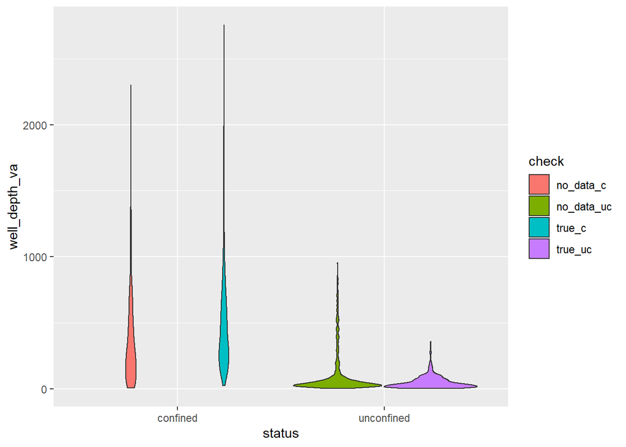

```r
# Data frame for plots
ggplot_modern <- nacp_modern_check %>%
  filter(!check %in% c("wrong_c", "wrong_uc")) %>%
  filter(!is.na(check))

# Violin plot comparing confined, unconfined and USGS data/no data
ggplot(ggplot_modern,
       aes(x = status,
           y = well_depth_va,
           fill = check)) +
  geom_violin()
```

Can’t figure out binning…how can this be so hard? (05/02/22)

```r
# # Binned data frame (~10 m intervals)
#
# ggplot_mod_bin <- ggplot_modern %>%
#   ungroup() %>%
#   mutate(depth_bin = dplyr::ntile(well_depth_va, 33)) %>%
#   mutate(confined_num = ifelse(status == "unconfined", 0, 1)) %>%
#   group_by(depth_bin) %>%
#   add_count(depth_bin)
#
# ggplot_mod_bin2 <- ggplot_modern %>%
#   ungroup() %>%
#   mutate(depth_bin = cut(well_depth_va, breaks = c(0, 33, 66, 99, ))
#
# test <- ggplot_modern %>%
#   ungroup() %>%
#   mutate(depth_bin =
#            case_when(well_depth_va <= 33 ~"1",
#                      well_depth_va <= 66 ~"2",
#                      well_depth_va <= 99 ~"3",
#                      TRUE ~"NA"))
#
#
#
# %>%
#   mutate(confined_num = ifelse(status == "unconfined", 0, 1)) %>%
#   group_by(depth_bin) %>%
#   add_count(depth_bin)
#
# breaks = seq(33 - )
```

#### Comparison of artesian conditions (confined wells only)

1900 to 2010-2020

```r
# All aquifers that are confined by our criteria, excluding "incorrect" ones (Modern) with USGS correction

# Modern wells
nacp_confined_mod <- nacp_modern_check %>%
  filter(check %in% c("true_c", "no_data_c")) %>%
  mutate(artesian =
           ifelse(median < 0, 1, 0))

# Write as tsv
write_csv(nacp_confined_mod, here::here("output_data", "nacp", "nacp_confined_mod.txt"))

# 1900 data
nacp_confined_1900 <- confined_criteria_1900 %>%
  filter(status == "confined")

# Write as tsv
write_csv(nacp_confined_1900, here::here("output_data", "nacp", "nacp_confined_historical.txt"))
```